# basic_search

The [Internet Movie Database (IMDb)](http://www.imdb.com/) provides information about movies, such as total budgets, lengths, actors, and user ratings. It is publicly available [here](http://www.imdb.com/interfaces). The examples below show basic methods for exploring and visualizing the imdb.csv dataset.

The downloaded file contains 4 columns separated by tab:

1. Title: title of the movie;
2. Year: release year;
3. Rating: average IMDb user rating;
4. Votes: number of IMDB users who rated this movie

There are 313,012 lines in the file.

```python
import pandas as pd
import numpy as np
import csv
import matplotlib.pyplot as plt
import seaborn as sns

%matplotlib inline
```

`matplotlib inline`, allows us to display plots within the notebook instead of creating figure files.

Python provides the [csv](https://docs.python.org/3.5/library/csv.html) module to read and write CSV files. The [`csv.reader`](https://docs.python.org/3.5/library/csv.html#csv.reader) function returns a Python object which will iterate over lines in the given file. Each line is returned as a list of strings, so that we can access a particular column using the list index. If we want to ignore the first line, we can use [`islice`](https://docs.python.org/3.5/library/itertools.html#itertools.islice). It is like slicing a list, but it can slice an iterator (e.g. file stream). For instance, `islice(reader, 0, 5)` means "give me the first 5 items from the `reader`." `islice(reader, 1, 5)` means "give me the 4 items starting from the second item."

```python
f = open('imdb.csv', 'r')
reader = csv.reader(f, delimiter='\t')
for row in islice(reader, 0, 5):
    print(row)
    print(row[1])
```

```
['Title', 'Year', 'Rating', 'Votes']
Year
['!Next?', '1994', '5.4', '5']
1994
['#1 Single', '2006', '6.1', '61']
2006
['#7DaysLater', '2013', '7.1', '14']
2013
['#Bikerlive', '2014', '6.8', '11']
2014
```

It's also very easy to read `CSV` files with `pandas`, using the [**`panda.read_csv()`**](http://pandas.pydata.org/pandas-docs/stable/generated/pandas.read_csv.html) function. This function has many options but there are things that you need to be careful about. For example:

1. `delimiter` or `sep`: the data file may use a comma, tab, or any weird character to separate fields. You can't read data properly if this option is incorrect.
2. `header`: some data files have a "header" row that contains the names of the columns. If you read it as data or use the first row as the header, you'll have problems.
3. `na_values` or `na_filter`: often the dataset is incomplete and contains missing data (`NA`, `NaN` (not a number), etc.). It's very important to take care of them properly.

You don't need to create dictionaries and other data structures. `Pandas` just imports the whole table into a data structure called [**`DataFrame`**](http://pandas.pydata.org/pandas-docs/stable/generated/pandas.DataFrame.html).

```python
df = pd.read_csv('imdb.csv', delimiter='\t')
df.head()
```

|  | Title | Year | Rating | Votes |
| --- | --- | --- | --- | --- |
| 0 | !Next? | 1994 | 5.4 | 5 |
| 1 | #1 Single | 2006 | 6.1 | 61 |
| 2 | #7DaysLater | 2013 | 7.1 | 14 |
| 3 | #Bikerlive | 2014 | 6.8 | 11 |
| 4 | #ByMySide | 2012 | 5.5 | 13 |

There are different options for looking at the data in the first few rows.

```python
df.head(2)
```

|  | Title | Year | Rating | Votes |
| --- | --- | --- | --- | --- |
| 0 | !Next? | 1994 | 5.4 | 5 |
| 1 | #1 Single | 2006 | 6.1 | 61 |

```python
df['Year'].head(3)
```

```
0    1994
1    2006
2    2013
Name: Year, dtype: int64
```

```python
df[['Year','Rating']].head(3)
```

|  | Year | Rating |
| --- | --- | --- |
| 0 | 1994 | 5.4 |
| 1 | 2006 | 6.1 |
| 2 | 2013 | 7.1 |

```python
df[:10]
```

|  | Title | Year | Rating | Votes |
| --- | --- | --- | --- | --- |
| 0 | !Next? | 1994 | 5.4 | 5 |
| 1 | #1 Single | 2006 | 6.1 | 61 |
| 2 | #7DaysLater | 2013 | 7.1 | 14 |
| 3 | #Bikerlive | 2014 | 6.8 | 11 |
| 4 | #ByMySide | 2012 | 5.5 | 13 |
| 5 | #LawstinWoods | 2013 | 7.0 | 6 |
| 6 | #lovemilla | 2013 | 6.7 | 17 |
| 7 | #nitTWITS | 2011 | 7.1 | 9 |
| 8 | $#*! My Dad Says | 2010 | 6.3 | 4349 |
| 9 | $1,000,000 Chance of a Lifetime | 1986 | 6.4 | 16 |

```python
df[['Year','Rating']][:10]
```

|  | Year | Rating |
| --- | --- | --- |
| 0 | 1994 | 5.4 |
| 1 | 2006 | 6.1 |
| 2 | 2013 | 7.1 |
| 3 | 2014 | 6.8 |
| 4 | 2012 | 5.5 |
| 5 | 2013 | 7.0 |
| 6 | 2013 | 6.7 |
| 7 | 2011 | 7.1 |
| 8 | 2010 | 6.3 |
| 9 | 1986 | 6.4 |

The [**`value_counts()`**](http://pandas.pydata.org/pandas-docs/stable/generated/pandas.Series.value_counts.html) function counts how many times each data value appears.

```python
print( min(df['Year']), df['Year'].min(), max(df['Year']), df['Year'].max() )
year_nummovies = df["Year"].value_counts()
year_nummovies.head()
```

```
1874 1874 2017 2017
```

```
2011    13944
2012    13887
2013    13048
2010    12931
2009    12268
Name: Year, dtype: int64
```

You can calculate average ratings and votes

```python
print( np.mean(df['Rating']), np.mean(df['Votes']) )
```

```
6.296195341377723 1691.2317746021706
```

```python
print( df['Rating'].mean() )
```

```
6.296195341377723
```

To get the median ratings of movies in 1990s, you first select only movies in that decade

```python
geq = df['Year'] >= 1990
leq = df['Year'] <= 1999
movie_nineties = df[geq & leq]
```

```python
movie_nineties.head()
```

|  | Title | Year | Rating | Votes |
| --- | --- | --- | --- | --- |
| 0 | !Next? | 1994 | 5.4 | 5 |
| 23 | 'N Sync TV | 1998 | 7.5 | 11 |
| 33 | 't Zal je gebeuren... | 1998 | 6.0 | 7 |
| 34 | 't Zonnetje in huis | 1993 | 6.1 | 148 |
| 42 | .COM | 1999 | 3.8 | 5 |

```python
print(movie_nineties['Rating'].median(), movie_nineties['Votes'].median())
```

```
6.3 32.0
```

Finally, if we want to know the top rated movies in 1990s, we can use the [**`sort()`**](http://pandas.pydata.org/pandas-docs/stable/generated/pandas.DataFrame.sort.html) function:

```python
sorted_by_rating = movie_nineties.sort_values('Rating', ascending=False)
sorted_by_rating[1:10]
```

|  | Title | Year | Rating | Votes |
| --- | --- | --- | --- | --- |
| 202778 | Nicole's Revenge | 1995 | 9.5 | 13 |
| 38899 | The Beatles Anthology | 1995 | 9.4 | 3822 |
| 39429 | The Civil War | 1990 | 9.4 | 4615 |
| 218444 | Pink Floyd: P. U. L. S. E. Live at Earls Court | 1994 | 9.3 | 3202 |
| 279320 | The Shawshank Redemption | 1994 | 9.3 | 1511933 |
| 72171 | Bardot | 1992 | 9.2 | 5 |
| 42590 | The Sopranos | 1999 | 9.2 | 163406 |
| 29419 | Otvorena vrata | 1994 | 9.1 | 2337 |
| 3955 | Baseball | 1994 | 9.1 | 2463 |

```python
print("The 10th percentile is", np.percentile(movie_nineties['Rating'], 10))
print()
print( "The median", movie_nineties['Rating'].median() )
print( "The mean", movie_nineties['Rating'].mean() )
print()
print("The 90th percentile is", np.percentile(movie_nineties['Rating'], 90))
```

```
The 10th percentile is 4.3

The median 6.3
The mean 6.183766787465408

The 90th percentile is 7.9
```

`Pandas` also provides some easy ways to draw plots by using `matplotlib`. A `Dataframe` object has several plotting functions such as:

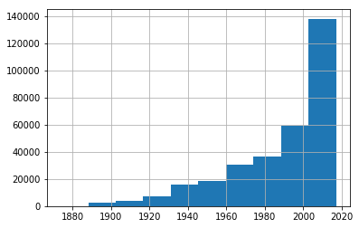

```python
df['Year'].hist()
```

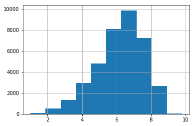

```python
movie_nineties['Rating'].hist()
```

You can also plot a histogram of ratings using the [**`pyplot.hist()`**](http://matplotlib.org/api/pyplot_api.html#matplotlib.pyplot.hist) function.

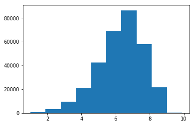

```python
plt.hist(df['Rating'], bins=10)
```

You can also try to make some style changes to the plot:

- change the color from blue to whatever you want
  - http://matplotlib.org/users/pyplot_tutorial.html#working-with-text
  - http://matplotlib.org/api/colors_api.html
- add labels of x and y axis
- change the number of bins to 20

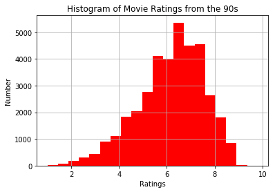

```python
plt.hist(movie_nineties['Rating'], bins = 20, color = "red")
plt.xlabel('Ratings')
plt.ylabel('Number')
plt.title('Histogram of Movie Ratings from the 90s')
plt.grid(True)
plt.show()
```

Seaborn sits on the top of matplotlib and makes it easier to draw statistical plots. Most plots that you create with Seaborn can be created with matplotlib, it just typically requires more work. We can use the [**`distplot()`**](http://stanford.edu/~mwaskom/software/seaborn/generated/seaborn.distplot.html) function to plot the histogram.

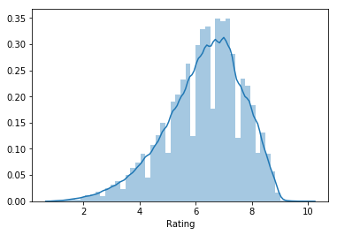

```python
sns.distplot(df['Rating'])
```

You can change adjust your plot in different ways such as changing bin size or removing the kde

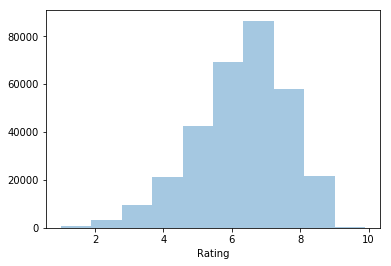

```python
sns.distplot(df['Rating'], bins = 10, kde= False)
```